# Data Science and Business Analytics

## Boosting - Model Building and Hyperparameter Tuning

### AdaBoost Classifier

```python
## define AdaBoost Classifier with random state = 1
ab_classifier = AdaBoostClassifier(random_state=1)

#code to fit AdaBoost Classifier on the train data
ab_classifier.fit(X_train, y_train)
```

```
AdaBoostClassifier(random_state=1)
```

#### Checking model performance on training set

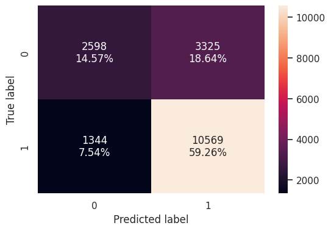

```python
confusion_matrix_sklearn(
    ab_classifier, X_train, y_train
)  ## Complete the code to create confusion matrix for train data
```

```python
#code to check performance metrics on train data using adaboost classifier
ab_classifier_model_train_perf = model_performance_classification_sklearn(
    ab_classifier, X_train, y_train)

ab_classifier_model_train_perf
```

|  | Accuracy | Recall | Precision | F1 |
| --- | --- | --- | --- | --- |
| 0 | 0.7382 | 0.8872 | 0.7607 | 0.8191 |

#### Checking model performance on test set

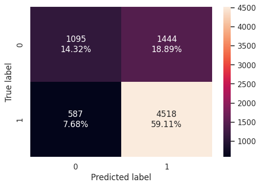

```python
#code to create confusion matrix for test data using adaboost classifier
confusion_matrix_sklearn(ab_classifier, X_test, y_test)
```

```python
#code to check performance metrics for test data using Adaboost
ab_classifier_model_test_perf = model_performance_classification_sklearn(
    ab_classifier, X_test, y_test)

ab_classifier_model_test_perf
```

|  | Accuracy | Recall | Precision | F1 |
| --- | --- | --- | --- | --- |
| 0 | 0.7343 | 0.8850 | 0.7578 | 0.8165 |

AdaBoost improves the performance of weak learners, and it is less prone to overfitting than a single Decision Tree.

Before hyperparameter tuning, the Random Forest and AdaBoost models perform better than the Decision Tree and Bagging models on the test data, with the AdaBoost model having a slightly better performance than the Random Forest model. (AdaBoost model had an accuracy of 0.7343 on the test data, which is slightly better than the Random Forest model )

### Hyperparameter Tuning - AdaBoost Classifier

```python
# Choose the type of classifier.
abc_tuned = AdaBoostClassifier(random_state=1)

# Grid of parameters to choose from
parameters = {
    # Let's try different max_depth for base_estimator
    "base_estimator": [
        DecisionTreeClassifier(max_depth=1, class_weight="balanced", random_state=1),
        DecisionTreeClassifier(max_depth=2, class_weight="balanced", random_state=1),
    ],
    "n_estimators": np.arange(80, 101, 10),
    "learning_rate": np.arange(0.1, 0.4, 0.1),
}

# Type of scoring used to compare parameter  combinations
acc_scorer = metrics.make_scorer(metrics.f1_score)

# Run the grid search with cv = 5
grid_obj = GridSearchCV(
    abc_tuned, parameters, scoring=acc_scorer, cv=5)

## fit the grid_obj on train data
grid_obj = grid_obj.fit(X_train, y_train)

# Set the clf to the best combination of parameters
abc_tuned = grid_obj.best_estimator_

# Fit the best algorithm to the data.
abc_tuned.fit(X_train, y_train)
```

```
AdaBoostClassifier(base_estimator=DecisionTreeClassifier(class_weight='balanced',
                                                         max_depth=1,
                                                         random_state=1),
                   learning_rate=0.1, n_estimators=100, random_state=1)
```

#### Checking model performance on training set

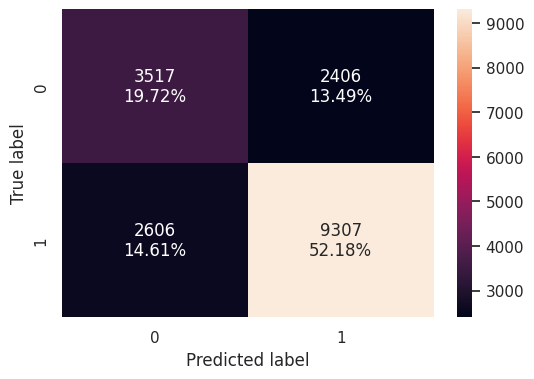

```python
#create confusion matrix for train data on tuned estimator
confusion_matrix_sklearn(abc_tuned, X_train, y_train)
```

```python
#check performance metrics for train data on tuned estimator
abc_tuned_model_train_perf = model_performance_classification_sklearn(
    abc_tuned, X_train, y_train)

abc_tuned_model_train_perf
```

|  | Accuracy | Recall | Precision | F1 |
| --- | --- | --- | --- | --- |
| 0 | 0.7190 | 0.7812 | 0.7946 | 0.7879 |